# Practical Machine Learning Course Project

Angela

4/8/2020

## Project Overview

Using devices such as Jawbone Up, Nike FuelBand, and Fitbit it is now possible to collect a large amount of data about personal activity relatively inexpensively. These type of devices are part of the quantified self movement – a group of enthusiasts who take measurements about themselves regularly to improve their health, to find patterns in their behavior, or because they are tech geeks. One thing that people regularly do is quantify how much of a particular activity they do, but they rarely quantify how well they do it.

In this [dataset](http://web.archive.org/web/20161224072740/http:/groupware.les.inf.puc-rio.br/har), six male participants aged between 20-28 years, with little weight lifting experience, were asked to perform one set of 10 repetitions of the Unilateral Dumbbell Biceps Curl in five different fashions.

- Each class is defined as:
  - exactly according to the specification (Class A)
  - throwing the elbows to the front (Class B)
  - lifting the dumbbell only halfway (Class C)
  - lowering the dumbbell only halfway (Class D)
  - throwing the hips to the front (Class E)

The goal of your project is to predict the manner in which they did the exercise. Class A corresponds to the specified execution of the exercise, while the other 4 classes correspond to common mistakes. Participants were supervised by an experienced weight lifter to make sure the execution complied to the manner they were supposed to simulate. We made sure that all participants could easily simulate the mistakes in a safe and controlled manner by using a relatively light dumbbell (1.25kg).

- You should create a report describing:
  - how you built your model
  - how you used cross validation
  - what you think the expected out of sample

## 1. Load all relevant packages

This includes the caret, rattle, randomForest, randomForestExplainer and cowplot packages. See versions used in Appendix - Figure 9.

## 2. Load data

```r
url <- "http://groupware.les.inf.puc-rio.br/static/WLE/WearableComputing_weight_lifting_exercises_biceps_curl_variations.csv"
df <- read.csv(url, header = TRUE, na.strings=c("NA","#DIV/0!",""))
```

## 3. Clean up data

```r
#Remove columns containing ALL NA values
df <- df[,colSums(is.na(df)) == 0]

#Remove all irrelevant columns that you will not need as predictors
df <- subset(df, select = -c(1:7))
```

## Separate data into testing and training datasets

The links provided for the class did not include the classe variable so my training and tests datasets will look slightly different as I took them from the main source and re-separated them.  
training: https://d396qusza40orc.cloudfront.net/predmachlearn/pml-training.csv  
testing: https://d396qusza40orc.cloudfront.net/predmachlearn/pml-testing.csv  
main source: http://web.archive.org/web/20161224072740/http:/groupware.les.inf.puc-rio.br/har  
See Figure 1 and 2 for more information on data.

```r
#Create training and testing datasets
inTrain <- createDataPartition(y = df$classe,
                               p=0.7, list = FALSE)
training <- df[inTrain,]
testing <- df[-inTrain,]
```

## 4. Create basic decision tree model and test

```r
set.seed(1234)

#Make simple decision tree model using rpart
model <- train(classe ~ ., data = training, method="rpart")

#Apply model to training dataset and see accuracy
rpartmodel_train <- predict(model, data = training)
CM_train <- confusionMatrix(training$classe, rpartmodel_train)

#Apply model to testing dataset and see accuracy
rpartmodel_test <- predict(model, newdata = testing)
rpart_CM_test <- confusionMatrix(testing$classe, rpartmodel_test)
```

## 5. Create random forest model and test

In order to improve our accuracy, we will use a random forest model. This model generates 100 decision trees (ntree) where each node splits based off of 7 variables (mtry) and gives us variable importance based on majority voting. Using random forest, both our training and testing datasets have an accuracy of >99% with a very small amount of misclassification (Figure 6-7). These can be visualized using multiway importance plots and variable importance plots (Figure 8).

```r
set.seed(2020)

#Generate random forest model
rfmodel <- randomForest(classe ~ ., data = training, method="rf", ntree=100, importance = TRUE)

#See how well the random forest model performs on training dataset
rfmodel_train <- predict(rfmodel, data = training)
rf_CM_train <- confusionMatrix(training$classe, rfmodel_train)

#See which variables are the most important in the training dataset
variableimportance <- importance(rfmodel)
variableimportance <- varImp(rfmodel)[1:10,]

min_depth_frame <- min_depth_distribution(rfmodel)
plot1 <- plot_min_depth_distribution(min_depth_frame)

importance_frame <- measure_importance(rfmodel)
plot2 <- plot_multi_way_importance(importance_frame, size_measure = "no_of_nodes")

#See how well the random forest model performs on testing dataset
rfmodel_test <- predict(rfmodel, newdata = testing)
rf_CM_test <- confusionMatrix(testing$classe, rfmodel_test)
```

## 7. Appendix

#### Figure 1. Name of all variables included in model

```
##  [1] "pitch_belt"           "yaw_belt"             "total_accel_belt"
##  [4] "gyros_belt_x"         "gyros_belt_y"         "gyros_belt_z"
##  [7] "accel_belt_x"         "accel_belt_y"         "accel_belt_z"
## [10] "magnet_belt_x"        "magnet_belt_y"        "magnet_belt_z"
## [13] "roll_arm"             "pitch_arm"            "yaw_arm"
## [16] "total_accel_arm"      "gyros_arm_x"          "gyros_arm_y"
## [19] "gyros_arm_z"          "accel_arm_x"          "accel_arm_y"
## [22] "accel_arm_z"          "magnet_arm_x"         "magnet_arm_y"
## [25] "magnet_arm_z"         "pitch_dumbbell"       "yaw_dumbbell"
## [28] "total_accel_dumbbell" "gyros_dumbbell_x"     "gyros_dumbbell_y"
## [31] "gyros_dumbbell_z"     "accel_dumbbell_x"     "accel_dumbbell_y"
## [34] "accel_dumbbell_z"     "magnet_dumbbell_x"    "magnet_dumbbell_y"
## [37] "magnet_dumbbell_z"    "roll_forearm"         "pitch_forearm"
## [40] "yaw_forearm"          "total_accel_forearm"  "gyros_forearm_x"
## [43] "gyros_forearm_y"      "gyros_forearm_z"      "accel_forearm_x"
## [46] "accel_forearm_y"      "accel_forearm_z"      "magnet_forearm_x"
## [49] "magnet_forearm_y"     "magnet_forearm_z"     "classe"
```

#### Figure 2. Dimensions of training and testing datasets

These datasets were split 70:30 where the training set had more data.

```
## [1] 27472    51
```

```
## [1] 11770    51
```

#### Figure 3. Rpart training information

```
##    rpartmodel_train
##        A    B    C    D    E
##   A 7030  177  571    1   33
##   B 2090 1693 1351  178    4
##   C 2234  182 2371    4    0
##   D 1936  106 1642  819    0
##   E 1116  815 1402  230 1487
```

```
##       Accuracy          Kappa  AccuracyLower  AccuracyUpper   AccuracyNull
##      0.4877694      0.3311328      0.4818420      0.4936994      0.5243885
## AccuracyPValue  McnemarPValue
##      1.0000000      0.0000000
```

#### Figure 4. Rpart testing information

```
##    rpartmodel_test
##        A    B    C    D    E
##   A 3021   81  226    0   19
##   B  910  747  546   72    2
##   C  910   67 1074    2    0
##   D  866   47  703  313    0
##   E  463  374  606  103  618
```

```
##       Accuracy          Kappa  AccuracyLower  AccuracyUpper   AccuracyNull
##      0.4904843      0.3346099      0.4814138      0.4995595      0.5242141
## AccuracyPValue  McnemarPValue
##      1.0000000      0.0000000
```

#### Figure 5. Rpart visualization

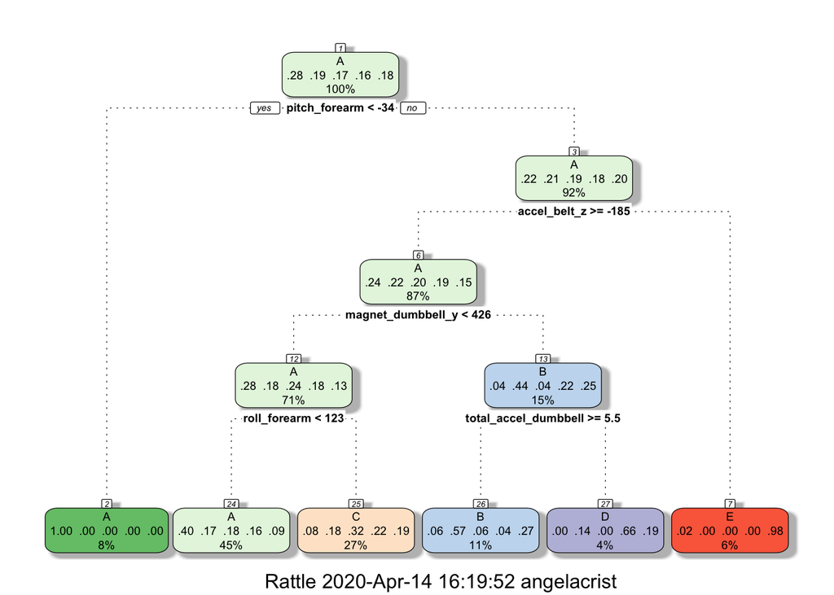

#### Figure 6. Random forest information - training

```
##    rfmodel_train
##        A    B    C    D    E
##   A 7810    1    0    1    0
##   B   10 5301    5    0    0
##   C    0    4 4785    2    0
##   D    0    0   13 4488    2
##   E    0    0    0    5 5045
```

```
##       Accuracy          Kappa  AccuracyLower  AccuracyUpper   AccuracyNull
##      0.9984348      0.9980202      0.9978922      0.9988670      0.2846535
## AccuracyPValue  McnemarPValue
##      0.0000000            NaN
```

```
## Confusion Matrix and Statistics
##
##           Reference
## Prediction    A    B    C    D    E
##          A 7810    1    0    1    0
##          B   10 5301    5    0    0
##          C    0    4 4785    2    0
##          D    0    0   13 4488    2
##          E    0    0    0    5 5045
##
## Overall Statistics
##
##                Accuracy : 0.9984
##                  95% CI : (0.9979, 0.9989)
##     No Information Rate : 0.2847
##     P-Value [Acc > NIR] : < 2.2e-16
##
##                   Kappa : 0.998
##
##  Mcnemar's Test P-Value : NA
##
## Statistics by Class:
##
##                      Class: A Class: B Class: C Class: D Class: E
## Sensitivity            0.9987   0.9991   0.9963   0.9982   0.9996
## Specificity            0.9999   0.9993   0.9997   0.9993   0.9998
## Pos Pred Value         0.9997   0.9972   0.9987   0.9967   0.9990
## Neg Pred Value         0.9995   0.9998   0.9992   0.9997   0.9999
## Prevalence             0.2847   0.1931   0.1748   0.1637   0.1837
## Detection Rate         0.2843   0.1930   0.1742   0.1634   0.1836
## Detection Prevalence   0.2844   0.1935   0.1744   0.1639   0.1838
## Balanced Accuracy      0.9993   0.9992   0.9980   0.9988   0.9997
```

```
##                          A         B         C         D         E
## pitch_belt       15.285906 23.723767 18.324389 17.578174 14.990533
## yaw_belt         26.876922 25.037151 21.385220 28.256454 20.275378
## total_accel_belt  8.799190 10.522703 10.425443 10.392550  8.517546
## gyros_belt_x      8.435274  7.662788  9.822535  7.627296 10.465899
## gyros_belt_y      5.546962  9.067736  9.082316  6.797262 12.112401
## gyros_belt_z     10.911501 15.065332 14.687639 13.486968 15.725091
## accel_belt_x      7.182894  9.129826  8.721689  6.040272  8.414980
## accel_belt_y      8.832301  8.426563  9.170814 10.340598  9.420449
## accel_belt_z     11.641927 12.824700 14.436748 12.844766 10.605464
## magnet_belt_x    10.138931 17.533113 17.142966 13.500721 15.801951
```

#### Figure 7. Random forest information - testing

```
##    rfmodel_test
##        A    B    C    D    E
##   A 3346    1    0    0    0
##   B   11 2265    1    0    0
##   C    0    2 2049    2    0
##   D    0    0    6 1921    2
##   E    0    0    0    1 2163
```

```
##       Accuracy          Kappa  AccuracyLower  AccuracyUpper   AccuracyNull
##      0.9977910      0.9972057      0.9967650      0.9985565      0.2852167
## AccuracyPValue  McnemarPValue
##      0.0000000            NaN
```

```
## Confusion Matrix and Statistics
##
##           Reference
## Prediction    A    B    C    D    E
##          A 3346    1    0    0    0
##          B   11 2265    1    0    0
##          C    0    2 2049    2    0
##          D    0    0    6 1921    2
##          E    0    0    0    1 2163
##
## Overall Statistics
##
##                Accuracy : 0.9978
##                  95% CI : (0.9968, 0.9986)
##     No Information Rate : 0.2852
##     P-Value [Acc > NIR] : < 2.2e-16
##
##                   Kappa : 0.9972
##
##  Mcnemar's Test P-Value : NA
##
## Statistics by Class:
##
##                      Class: A Class: B Class: C Class: D Class: E
## Sensitivity            0.9967   0.9987   0.9966   0.9984   0.9991
## Specificity            0.9999   0.9987   0.9996   0.9992   0.9999
## Pos Pred Value         0.9997   0.9947   0.9981   0.9959   0.9995
## Neg Pred Value         0.9987   0.9997   0.9993   0.9997   0.9998
## Prevalence             0.2852   0.1927   0.1747   0.1635   0.1839
## Detection Rate         0.2843   0.1924   0.1741   0.1632   0.1838
## Detection Prevalence   0.2844   0.1935   0.1744   0.1639   0.1839
## Balanced Accuracy      0.9983   0.9987   0.9981   0.9988   0.9995
```

#### Figure 8. Random forest visualization

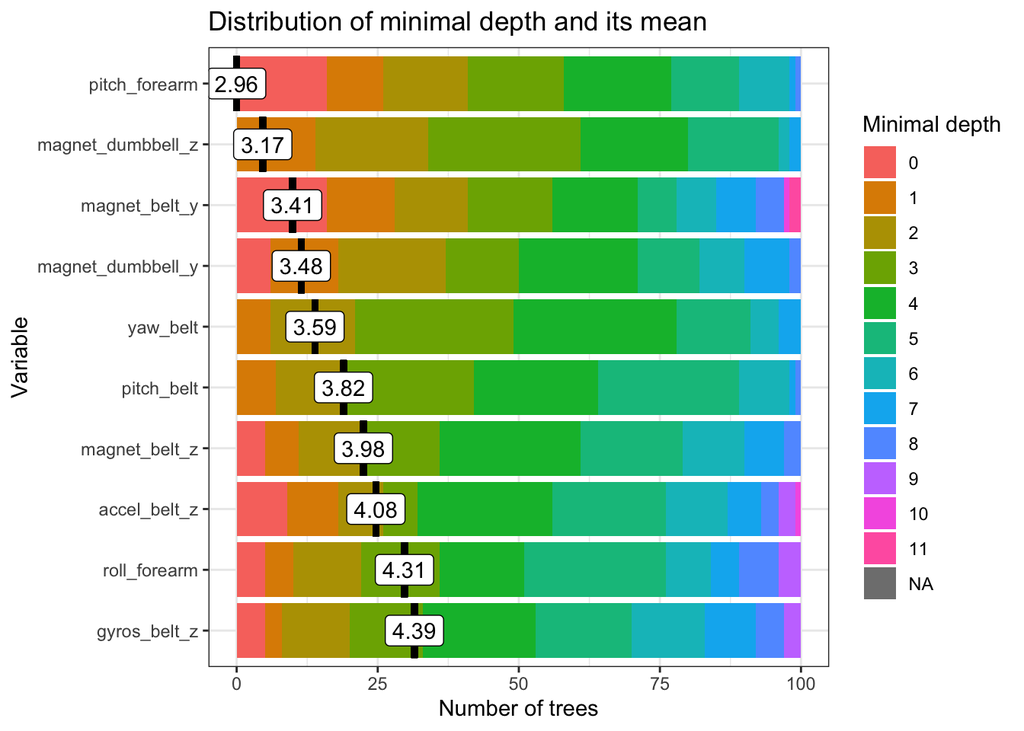

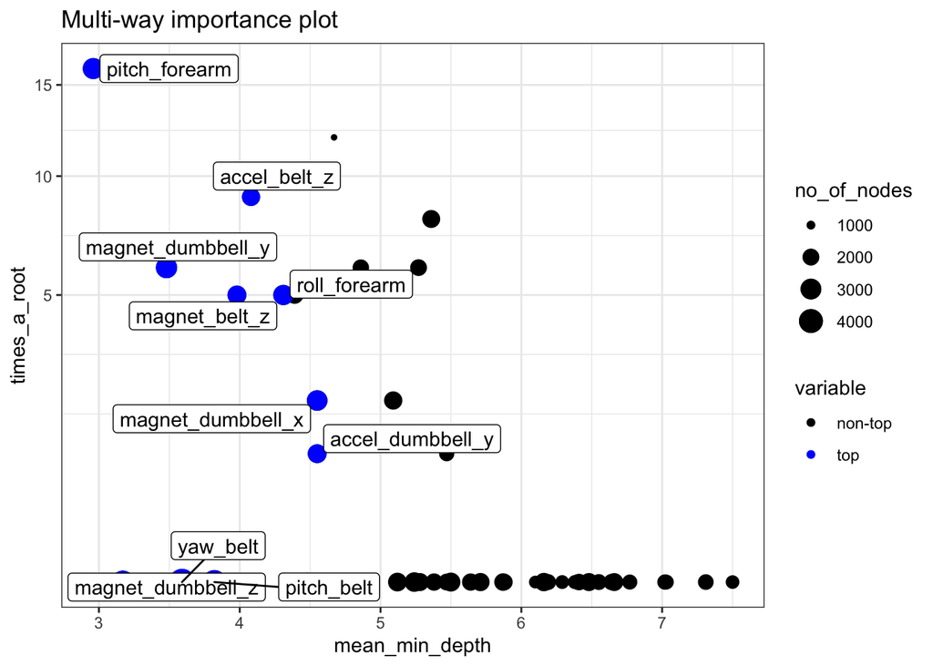

#### Figure 9. List of all packages used and what version

```r
version$version.string
```

```
## [1] "R version 3.5.3 (2019-03-11)"
```

```r
packageVersion("caret", lib.loc = NULL)
```

```
## [1] '6.0.85'
```

```r
packageVersion("rattle", lib.loc = NULL)
```

```
## [1] '5.3.0'
```

```r
packageVersion("randomForest", lib.loc = NULL)
```

```
## [1] '4.6.14'
```

```r
packageVersion("randomForestExplainer", lib.loc = NULL)
```

```
## [1] '0.10.0'
```

```r
packageVersion("cowplot", lib.loc = NULL)
```

```
## [1] '1.0.0'
```